# Reproducible Research: Peer Assessment 1

## Loading and preprocessing the data

```r
setwd("/Users/ktarkhan/RStat/Datafiles")
data <- read.csv("/Users/ktarkhan/RStat/Datafiles/activity.csv")
```

## What is mean total number of steps taken per day?

```r
totals <- tapply(data$steps, data$date, sum, na.rm=T)
total_mean <- mean(totals, na.rm=T)
total_median <- median(totals, na.rm=T)
```

The mean total number of steps per day in this study was 9354. The median number of steps per day was 10395.

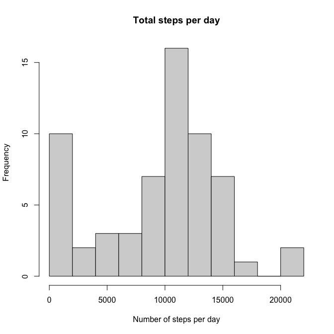

```r
hist(totals, breaks=10, xlab="Number of steps per day", main="Total steps per day")
```

## What is the average daily activity pattern?

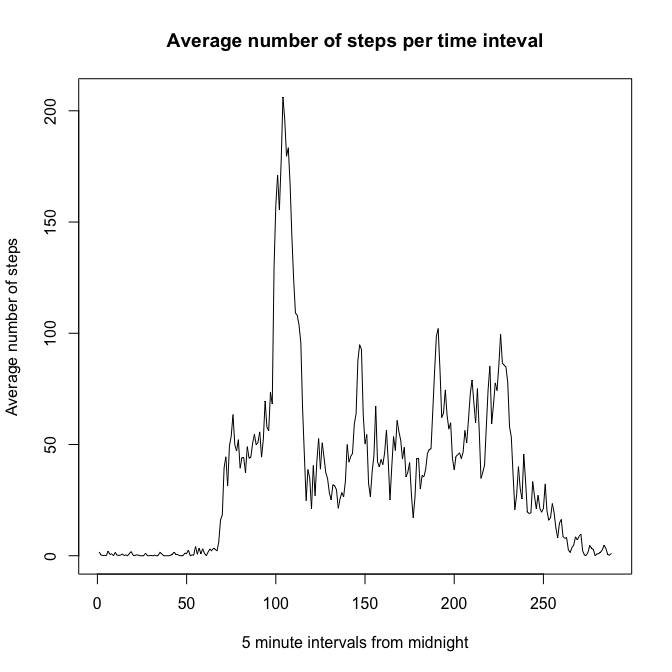

```r
avg_activity <- tapply(data$steps, data$interval, mean, na.rm=T)
plot(avg_activity, type="l", xlab="5 minute intervals from midnight", ylab="Average number of steps", main="Average number of steps per time inteval")
```

```r
max_int <- which.max(avg_activity)
```

The time of maximum average activity over the study period was 8:40.

## Imputing missing values

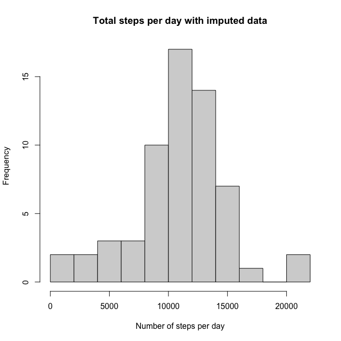

```r
library(dplyr)
data <- mutate(data, missing=is.na(data$steps))
nas <- tapply(data$missing, data$interval, sum)
data$week <- weekdays(as.Date(data$date))

misses <- data%>% filter(missing== TRUE)
missed_days <- data.frame(date=unique(misses$date))
missed_days$week <- weekdays(as.Date(missed_days$date))
data_imputed <- data
by_week <- data %>% group_by(week,interval) %>% summarise(avg=mean(steps, na.rm=T))
by_week <- ungroup(by_week)
all_rows <- nrow(data_imputed)
for(i in 1:all_rows) {
    if (is.na(data_imputed[i,"steps"])) {
        data_imputed[i, "steps"] <-  as.numeric(by_week %>%
            filter(week ==data_imputed[i,"week"] & interval == data_imputed[i,"interval"]) %>%
            select(avg))
    }
}

totals_imp <- tapply(data_imputed$steps, data_imputed$date, sum, na.rm=T)
total_mean_imp <- mean(totals_imp, na.rm=T)
total_median_imp <- median(totals_imp, na.rm=T)

hist(totals_imp, breaks=10, xlab="Number of steps per day", main="Total steps per day with imputed data")
```

Assuming that days of the week affect the patterns of behavior, we replace the missing values with the average values for the corresponding day of the week and the interval.

The mean total number of steps per day with the missing data imputed was 10821. The median number of steps per day was 11015.

## Are there differences in activity patterns between weekdays and weekends?

```r
weekly <- data %>% group_by(week) %>% summarise(total=sum(steps, na.rm=T))
weekdays <- data %>% filter(week %in% c("Monday", "Tuesday", "Wednesday", "Thursday", "Friday"))
weekends <- data %>% filter (week %in% c("Saturday", "Sunday"))

wd_totals <- tapply(weekdays$steps, weekdays$date, sum, na.rm=T)
wd_total_mean <- mean(wd_totals, na.rm=T)
wd_total_median <- median(wd_totals, na.rm=T)

we_totals <- tapply(weekends$steps, weekends$date, sum, na.rm=T)
we_total_mean <- mean(we_totals, na.rm=T)
we_total_median <- median(we_totals, na.rm=T)


wd_avg_activity <- tapply(weekdays$steps, weekdays$interval, mean, na.rm=T)
wd_max_int <- which.max(wd_avg_activity)
we_avg_activity <- tapply(weekends$steps, weekends$interval, mean, na.rm=T)
we_max_int <- which.max(we_avg_activity)
```

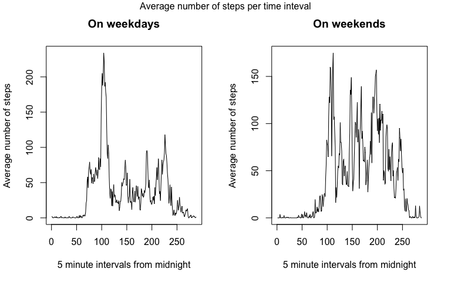

```r
par (mfrow=c(1,2))
plot(wd_avg_activity, type="l", xlab="5 minute intervals from midnight", ylab="Average number of steps", main="On weekdays")

plot(we_avg_activity, type="l", xlab="5 minute intervals from midnight", ylab="Average number of steps", main="On weekends")
mtext("Average number of steps per time inteval", side = 3,, line=-1, outer=T)
```

The time of maximum average activity on weekdays was 8:40.  
The time of maximum average activity on weekends was 9:20. They are close, weekends peaking a little later than weekdays.

The mean total number of steps per day on weekdays was 8820. The median number of steps on weekdays was 10056. The mean total number of steps per day on weekends was 10856. The median number of steps on weekends was 11646. Evidently the subjects walked more on weekends than on weekdays and the activity is distributed over the entire day more evenly on weekends.